# Data 607 Tidyverse CREATE Assignment

Leticia Salazar

2021-10-24

### Objective:

#### Your task here is to Create an Example. Using one or more TidyVerse packages, and any dataset from fivethirtyeight.com or Kaggle, create a programming sample “vignette” that demonstrates how to use one or more of the capabilities of the selected TidyVerse package with your selected dataset.

#### I am using a data set from [Kaggle.com](https://www.kaggle.com/johnsmith88/heart-disease-dataset) called Heart Disease Dataset. I have used this data set before but with Python [Care For Your Heart](https://letisalbal.github.io/Final-Project/). While there are plenty of Tidyverse packages to use I will be using ‘dplyr’, ‘tidyr’ and ‘ggplot2’ to demonstrate how to explore data sets in a simple but quick form.

### Description of the Data set:

#### This data set includes dates from 1988 from four different countries: Cleveland, Hungary, Switzerland and Long Beach Virginia. Below is a description of the columns:

[output not shown]

### Install packages and load libraries:

```r
# load libraries needed
library("tidyverse")
```

```r
library("dplyr")
library("tidyr")
library("ggplot2")
library("hrbrthemes")
# install packages if not already
# install.packages("tidyverse")
# install.packages("dplyr")
# install.packages("tidyr")
# install.packages("ggplot2")
# hrbrthemes::import_roboto_condensed()
```

### Load file into R:

```r
# load csv file
heart_disease <- read.csv("https://raw.githubusercontent.com/letisalba/Data-607/main/Tidyverse/heart.csv", header = TRUE, na = ",")
head(heart_disease, n = 4) # by adding n = followed by any number you can select how many rows are to display
```

```
##   age sex cp trestbps chol fbs restecg thalach exang oldpeak slope ca thal
## 1  52   1  0      125  212   0       1     168     0     1.0     2  2    3
## 2  53   1  0      140  203   1       0     155     1     3.1     0  0    3
## 3  70   1  0      145  174   0       1     125     1     2.6     0  0    3
## 4  61   1  0      148  203   0       1     161     0     0.0     2  1    3
##   target
## 1      0
## 2      0
## 3      0
## 4      0
```

### Data Exploration:

#### With the ‘glimpse’ function you have an overview of the columns and rows of the data. Within this data set we have 1,025 rows and 14 columns. Most columns are integer while column ‘oldpeak’ is double class since it has a decimal point.

```r
# glimpse function
glimpse(heart_disease)
```

```
## Rows: 1,025
## Columns: 14
## $ age      <int> 52, 53, 70, 61, 62, 58, 58, 55, 46, 54, 71, 43, 34, 51, 52, 3…
## $ sex      <int> 1, 1, 1, 1, 0, 0, 1, 1, 1, 1, 0, 0, 0, 1, 1, 0, 0, 1, 0, 1, 1…
## $ cp       <int> 0, 0, 0, 0, 0, 0, 0, 0, 0, 0, 0, 0, 1, 0, 0, 1, 2, 0, 1, 2, 2…
## $ trestbps <int> 125, 140, 145, 148, 138, 100, 114, 160, 120, 122, 112, 132, 1…
## $ chol     <int> 212, 203, 174, 203, 294, 248, 318, 289, 249, 286, 149, 341, 2…
## $ fbs      <int> 0, 1, 0, 0, 1, 0, 0, 0, 0, 0, 0, 1, 0, 0, 1, 0, 0, 0, 0, 1, 0…
## $ restecg  <int> 1, 0, 1, 1, 1, 0, 2, 0, 0, 0, 1, 0, 1, 1, 1, 1, 0, 0, 1, 0, 0…
## $ thalach  <int> 168, 155, 125, 161, 106, 122, 140, 145, 144, 116, 125, 136, 1…
## $ exang    <int> 0, 1, 1, 0, 0, 0, 0, 1, 0, 1, 0, 1, 0, 1, 1, 0, 0, 1, 0, 0, 0…
## $ oldpeak  <dbl> 1.0, 3.1, 2.6, 0.0, 1.9, 1.0, 4.4, 0.8, 0.8, 3.2, 1.6, 3.0, 0…
## $ slope    <int> 2, 0, 0, 2, 1, 1, 0, 1, 2, 1, 1, 1, 2, 1, 1, 2, 2, 1, 2, 2, 1…
## $ ca       <int> 2, 0, 0, 1, 3, 0, 3, 1, 0, 2, 0, 0, 0, 3, 0, 0, 1, 1, 0, 0, 0…
## $ thal     <int> 3, 3, 3, 3, 2, 2, 1, 3, 3, 2, 2, 3, 2, 3, 0, 2, 2, 3, 2, 2, 2…
## $ target   <int> 0, 0, 0, 0, 0, 1, 0, 0, 0, 0, 1, 0, 1, 0, 0, 1, 1, 0, 1, 1, 0…
```

#### The ‘summary’ function gives futher detail about the data such as minimum, maximum, mean, median and IQR for each column or you can do individual columns as well.

```r
# summary function for whole data set
summary(heart_disease)
```

```
##       age             sex               cp            trestbps
##  Min.   :29.00   Min.   :0.0000   Min.   :0.0000   Min.   : 94.0
##  1st Qu.:48.00   1st Qu.:0.0000   1st Qu.:0.0000   1st Qu.:120.0
##  Median :56.00   Median :1.0000   Median :1.0000   Median :130.0
##  Mean   :54.43   Mean   :0.6956   Mean   :0.9424   Mean   :131.6
##  3rd Qu.:61.00   3rd Qu.:1.0000   3rd Qu.:2.0000   3rd Qu.:140.0
##  Max.   :77.00   Max.   :1.0000   Max.   :3.0000   Max.   :200.0
##       chol          fbs            restecg          thalach
##  Min.   :126   Min.   :0.0000   Min.   :0.0000   Min.   : 71.0
##  1st Qu.:211   1st Qu.:0.0000   1st Qu.:0.0000   1st Qu.:132.0
##  Median :240   Median :0.0000   Median :1.0000   Median :152.0
##  Mean   :246   Mean   :0.1493   Mean   :0.5298   Mean   :149.1
##  3rd Qu.:275   3rd Qu.:0.0000   3rd Qu.:1.0000   3rd Qu.:166.0
##  Max.   :564   Max.   :1.0000   Max.   :2.0000   Max.   :202.0
##      exang           oldpeak          slope             ca
##  Min.   :0.0000   Min.   :0.000   Min.   :0.000   Min.   :0.0000
##  1st Qu.:0.0000   1st Qu.:0.000   1st Qu.:1.000   1st Qu.:0.0000
##  Median :0.0000   Median :0.800   Median :1.000   Median :0.0000
##  Mean   :0.3366   Mean   :1.072   Mean   :1.385   Mean   :0.7541
##  3rd Qu.:1.0000   3rd Qu.:1.800   3rd Qu.:2.000   3rd Qu.:1.0000
##  Max.   :1.0000   Max.   :6.200   Max.   :2.000   Max.   :4.0000
##       thal           target
##  Min.   :0.000   Min.   :0.0000
##  1st Qu.:2.000   1st Qu.:0.0000
##  Median :2.000   Median :1.0000
##  Mean   :2.324   Mean   :0.5132
##  3rd Qu.:3.000   3rd Qu.:1.0000
##  Max.   :3.000   Max.   :1.0000
```

```r
# summary function for particular columns
summary(heart_disease$chol)
```

```
##    Min. 1st Qu.  Median    Mean 3rd Qu.    Max.
##     126     211     240     246     275     564
```

#### Checking for NA or missing values is crutial to assure accuracy in the data. By using colSums(is.na(df)) function you can check if there are any NA values in the data set.

```r
# checking for any NA values in columns
colSums(is.na(heart_disease))
```

```
##      age      sex       cp trestbps     chol      fbs  restecg  thalach
##        0        0        0        0        0        0        0        0
##    exang  oldpeak    slope       ca     thal   target
##        0        0        0        0        0        0
```

#### The ‘colnames’ function brings up the names of your columns in your data set

```r
# get column names
colnames(heart_disease)
```

```
##  [1] "age"      "sex"      "cp"       "trestbps" "chol"     "fbs"
##  [7] "restecg"  "thalach"  "exang"    "oldpeak"  "slope"    "ca"
## [13] "thal"     "target"
```

### Data Wrangling:

#### Using the ‘names’ function you can rename your whole data set

```r
# rename columns in data set
names(heart_disease) <- c('Age', 'Gender', 'Chest_Pain_Type', 'Resting_Blood_Pressure', 'Cholesterol', 'Fasting_Blood_Sugar', 'Resting_ECG', 'Thalach', 'Exercise_Induced_Angina', 'Oldpeak', 'Slope', 'Num_Major_Vessels', 'Thalassemia', 'Target')

# rename one column in data set
# names(heart_disease)[1] <- 'Age' # [1] the number in the bracket is the column number you would like to change

head(heart_disease, n = 2)
```

```
##   Age Gender Chest_Pain_Type Resting_Blood_Pressure Cholesterol
## 1  52      1               0                    125         212
## 2  53      1               0                    140         203
##   Fasting_Blood_Sugar Resting_ECG Thalach Exercise_Induced_Angina Oldpeak Slope
## 1                   0           1     168                       0     1.0     2
## 2                   1           0     155                       1     3.1     0
##   Num_Major_Vessels Thalassemia Target
## 1                 2           3      0
## 2                 0           3      0
```

```r
# replace gender values 1 = Male and 0 = Female; Fasting_blood_sugar values 1 = True and 0 = False; Exercise_Induced_Angina values 1 = Yes and 0 = No; Thalassemia values 0 = Normal, 1 = Fixed Defect and 2 = Reversible Defect; and Target values 0 = No Disease and 1 = Disease

heart <- heart_disease %>%
  mutate(Gender = replace(Gender, Gender == 1, 'Male')) %>%
  mutate(Gender = replace(Gender, Gender == 0, 'Female')) %>%

  mutate(Fasting_Blood_Sugar = replace(Fasting_Blood_Sugar, Fasting_Blood_Sugar == 1, 'True')) %>%
  mutate(Fasting_Blood_Sugar = replace(Fasting_Blood_Sugar, Fasting_Blood_Sugar == 0, 'False')) %>%

  mutate(Exercise_Induced_Angina = replace(Exercise_Induced_Angina, Exercise_Induced_Angina == 1, 'Yes')) %>%
  mutate(Exercise_Induced_Angina = replace(Exercise_Induced_Angina, Exercise_Induced_Angina == 0, 'No')) %>%

  mutate(Thalassemia = replace(Thalassemia, Thalassemia == 1, 'Normal')) %>%
  mutate(Thalassemia = replace(Thalassemia, Thalassemia == 2, 'Fixed Defect')) %>%
  mutate(Thalassemia = replace(Thalassemia, Thalassemia == 3, 'Reversible Defect')) %>%

  mutate(Target = replace(Target, Target == 0, 'No Disease')) %>%
  mutate(Target = replace(Target, Target == 1, 'Disease'))

head(heart, n = 4)
```

```
##   Age Gender Chest_Pain_Type Resting_Blood_Pressure Cholesterol
## 1  52   Male               0                    125         212
## 2  53   Male               0                    140         203
## 3  70   Male               0                    145         174
## 4  61   Male               0                    148         203
##   Fasting_Blood_Sugar Resting_ECG Thalach Exercise_Induced_Angina Oldpeak Slope
## 1               False           1     168                      No     1.0     2
## 2                True           0     155                     Yes     3.1     0
## 3               False           1     125                     Yes     2.6     0
## 4               False           1     161                      No     0.0     2
##   Num_Major_Vessels       Thalassemia     Target
## 1                 2 Reversible Defect No Disease
## 2                 0 Reversible Defect No Disease
## 3                 0 Reversible Defect No Disease
## 4                 1 Reversible Defect No Disease
```

### Data Analysis:

#### When it comes to graphing I like to use [r-graph-gallery](https://www.r-graph-gallery.com/index.html) for my graphing selection.

#### Graph 1 shows the range of ages in this data set that start from mid-20’s to late 70’s. Majority of the population is centered around the ages of 50’s - 60’s.

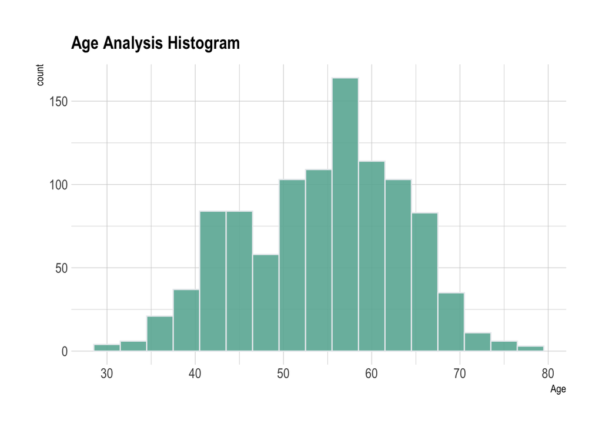

```r
# Age Analysis histogram

age_histogram <- heart %>%
  ggplot(aes(x = Age)) +
  geom_histogram( binwidth=3, fill="#69b3a2", color="#e9ecef", alpha=0.9) +
    ggtitle("Age Analysis Histogram") +
    theme_ipsum() +
    theme(
      plot.title = element_text(size=15)
    )
age_histogram
```

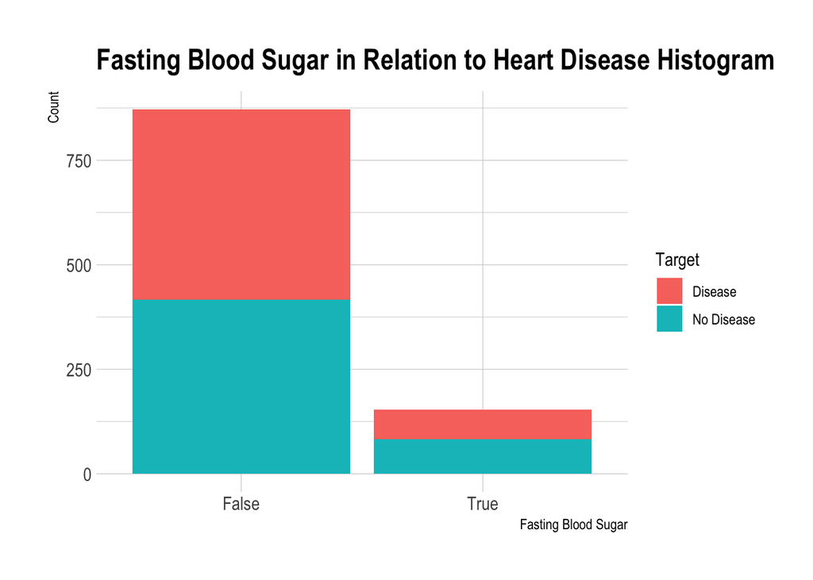

```r
# Age and Chest Pain Type histogram

barplot <- heart %>%
  ggplot(aes(x = Fasting_Blood_Sugar, fill = Target)) +
    geom_bar()  +
    ggtitle("Fasting Blood Sugar in Relation to Heart Disease Histogram") +
    xlab("Fasting Blood Sugar") +
    ylab("Count") +
    theme_ipsum() +
    theme(legend.position="right")
barplot
```

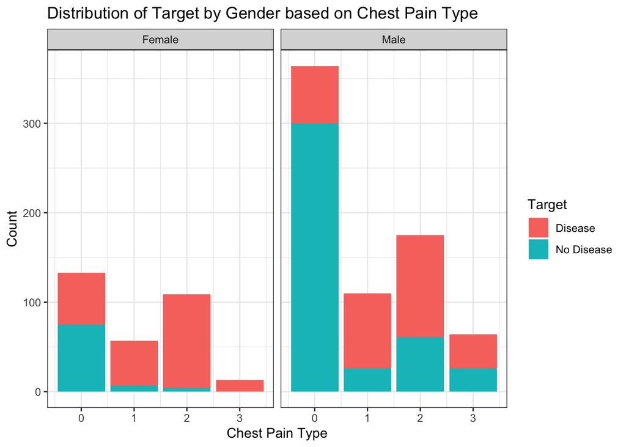

```r
# side by side bar plot
plot <- heart %>%
  ggplot(aes(x= Chest_Pain_Type,fill= Target)) +
    theme_bw() +
    geom_bar() +
    facet_wrap(~Gender) +
    labs(x = "Chest Pain Type",
         y = "Count",
       title = "Distribution of Target by Gender based on Chest Pain Type")
plot
```

#### Lastly, graph 4 is a scatterplot between resting blood pressure and cholesterol.There is a positive relationship between both of these values as the linear regression line moves slightly upward from left to right.

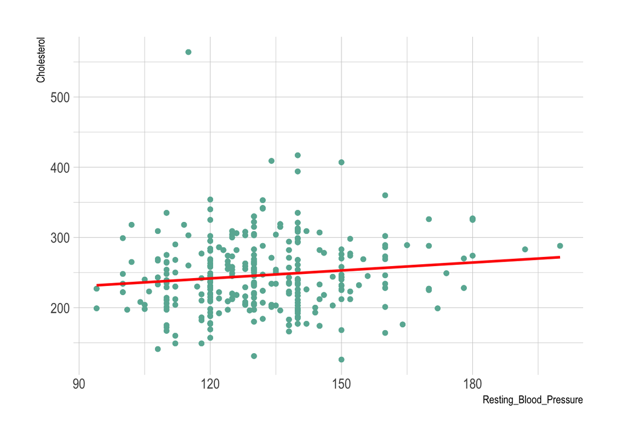

```r
# Blood Pressure and Cholesterol scatter plot

scatterplot <- heart %>%
  ggplot(aes(x = Resting_Blood_Pressure, y = Cholesterol)) +
  geom_point(color = "#69b3a2") +
  geom_smooth(method = lm , color="red", se = FALSE) +
  theme_ipsum()
scatterplot
```